# How Confident are AI Classifiers About Their Own Confidence?

Injury classsification using the 2024 NEISS

Python

Large Language Models

Author

Gio Circo, Ph.D.

Published

April 8, 2026

## AI ‘Confidence’ Scores

LLMs have found a lot of practical uses as text classifiers across a ton of different areas. In my day job we commonly use them to sort and classify documents into different categories for routing or processing. I would say these have largely supplanted the previous generation of BERT-esque based neural network models for natural language processing. Indeed, LLMs are typically quite good at a variety of classification tasks with fairly minimal instructions or pre-training required.

### How confident is “confident”?

However, getting classification “probabilities” from an LLM is a bit more challenging than from conventional machine learning or neural network approaches. LLMs don’t have an analogous `fit.predict_proba(X)` to retrieve classification probabilities. There are really two ways that I have seen this done for LLM classification models. Broadly speaking, they are:

1. Prompt the LLM to estimate its confidence in the classification and return the result in the output
2. Directly extract token-level probabilities from the model output

## Extracting Primary Injuries from the NEISS

As a source of data for this test, I used the National Electronic Injury Surveillance System (NEISS). This is a useful source of information for testing extraction schemes because they contain hundreds of thousands of labeled examples with short medical narratives. Most of them look akin to this:

> “26YOM STEPPED ON A NAIL WITH HIS RIGHT FOOT YESTERDAY AND STATES IT IS PAINFUL AND SWOLLEN DX: PUNCTURE WOUND RIGHT FOOT”

For my testing purposes, I wrote an LLM-based extraction pipeline to review the medical narrative and then classify the *primary* injury described in the narrative. I ran a batch process on a sample of 500 narratives using `gpt-5-nano` as the LLM.

If you’re interested, the full set of code is [here](https://github.com/gmcirco/neiss-injury-classifier/tree/main). The real important parts are just the extraction schema and the prompt. The rest is just routing stuff to OpenAI’s batch process. For the prompt I provide the full set of rules from the relevant section in the [NEISS coding manual](https://www.cpsc.gov/s3fs-public/January-2024-NEISS-CPSC-only-Coding-Manual.pdf?VersionId=bEaz2iKYDAlz8KA60KEKKrLrXZW3kLOj) for body parts. In addition, I add a sampling of labeled examples to help ground the AI with some real values (so called “few shot” or “k-shot” examples). In general, the extraction setup is quite minimal. Below I include the extraction schema, and the full prompt is [here](https://github.com/gmcirco/neiss-injury-classifier/blob/main/src/prompt.py).

### Extraction Schema

```python
class BodyPart(str, Enum):
    INTERNAL = "0"
    SHOULDER = "30"
    UPPER_TRUNK = "31"
    ELBOW = "32"
    LOWER_ARM = "33"
    WRIST = "34"
    KNEE = "35"
    LOWER_LEG = "36"
    ANKLE = "37"
    PUBIC_REGION = "38"
    HEAD = "75"
    FACE = "76"
    EYEBALL = "77"
    LOWER_TRUNK = "79"
    UPPER_ARM = "80"
    UPPER_LEG = "81"
    HAND = "82"
    FOOT = "83"
    BODY_25_50_PERCENT = "84"
    ALL_PARTS_BODY = "85"
    NOT_STATED_UNKNOWN = "87"
    MOUTH = "88"
    NECK = "89"
    FINGER = "92"
    TOE = "93"
    EAR = "94"


class InjuryClassification(BaseModel):
    body_part: BodyPart = Field(
        description="ID code for the primary body part injured or involved in the narrative"
    )
    reasoning: str = Field(
        description="10 word or less description of why the body part was chosen"
    )
    confidence: float = Field(
        description=(
            "Confidence of the body part classification as a float from 0.0 to 1.0, "
            "where 1.0 is absolute certainty, and 0.0 is completely unknown"
        )
    )
```

### Classification probabilities

The goal is to get output that looks like this below:

```json
{"body_part": 88, "reasoning": "Diagnosis states upper lip laceration.", "confidence": 0.98}
```

My definition of “confidence” is intentionally kept fairly vague. I just tell the AI to keep it in the range of “absolute certainty” and “completely unknown”. In my experience, most applications I have seen using confidence scores apply even less structure than this.

For token probabilities, I extract them directly from the response payload, and get the top 5 in a format like this below:

```json
"top_logprobs": [
                {
                    "token": "88",
                    "logprob": -0.0009117019944824278
                },
                {
                    "token": "76",
                    "logprob": -7.219661712646484
                },
                {
                    "token": "80",
                    "logprob": -10.270442962646484
                },
                {
                    "token": "30",
                    "logprob": -10.481380462646484
                },
                {
                    "token": "75",
                    "logprob": -10.715755462646484
                }
            ]
```

After running the model we get a fairly respectable accuracy of **86%**. I have no doubt that some more detailed prompting and k-shot examples could easily get this north of 95%.

### Evaluating confidence scores

The biggest drawback with these confidence scores is shared with many other classifiers: they are unlikely to be well *calibrated*. This means that there is no guarantee that the probabilities returned from the model closely map to the observed distribution of correct classifications. For example, a 95% probability in a well-calibrated model should expect to return a correct classification 95% of the time. Well-calibrated predictions are useful because they can help easily track to specific business KPIs.

We can quickly get a summary of the confidence scores for the 500 classifications. Below, I have a calibration plot and table for both the AI-generated confidence scores, and the token probability. Looking at the two approaches, there are some notable differences. On the upper end the AI-generated confidence scores are actually really quite close to reality. It’s only outside the upper end that there is clear divergence. For example, the AI estimates a mean confidence of about 45% for 7 cases, but is 100% correct!

While neither is terribly well-calibrated outside the highest upper-end, the token log-probabilities are highly over-confident relative to the AI-generated ones.

**AI Confidence**

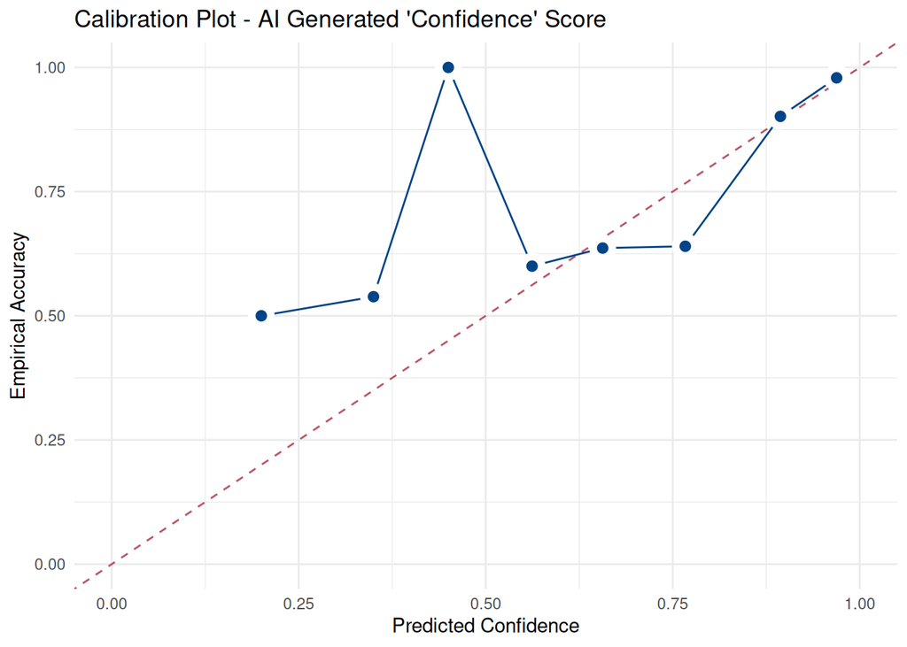

| bin | mean_conf | accuracy | n |
| --- | --- | --- | --- |
| (0.1,0.2] | 0.20 | 0.50 | 12 |
| (0.3,0.4] | 0.35 | 0.54 | 13 |
| (0.4,0.5] | 0.45 | 1.00 | 7 |
| (0.5,0.6] | 0.56 | 0.60 | 25 |
| (0.6,0.7] | 0.66 | 0.64 | 22 |
| (0.7,0.8] | 0.77 | 0.64 | 50 |
| (0.8,0.9] | 0.89 | 0.90 | 132 |
| (0.9,1] | 0.97 | 0.98 | 239 |

**Token Log-Probability**

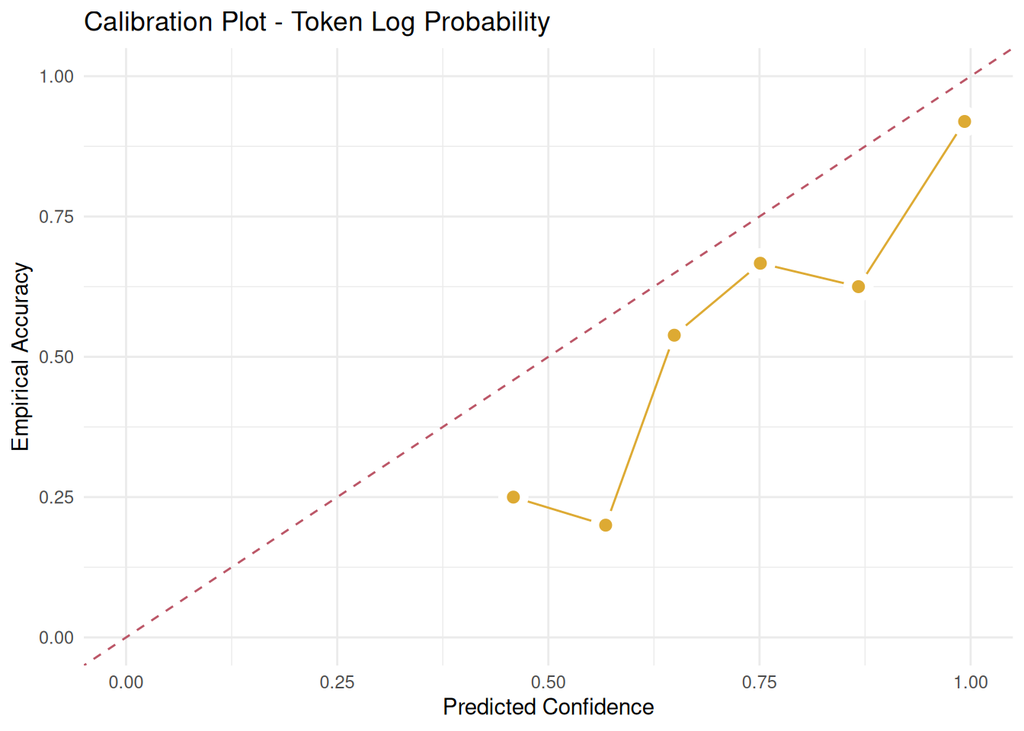

| bin | mean_conf | accuracy | n |
| --- | --- | --- | --- |
| (0.4,0.5] | 0.46 | 0.25 | 4 |
| (0.5,0.6] | 0.57 | 0.20 | 10 |
| (0.6,0.7] | 0.65 | 0.54 | 13 |
| (0.7,0.8] | 0.75 | 0.67 | 15 |
| (0.8,0.9] | 0.87 | 0.62 | 24 |
| (0.9,1] | 0.99 | 0.92 | 434 |

## Calibrating probabilities

```r
# get the correct labels and token probabilities
correct <- res$is_correct
pred_prob <- res$body_part_logprob_prob_1

# Do a top-versus-all calibration
# using isotonic step function
tva_iso <- isoreg(pred_prob, correct)
tva_predict <- as.stepfun(tva_iso)
calibrated_conf_iso <- tva_predict(pred_prob)

# check what a token probability of .85 now maps to
print(tva_predict(.85))
```

```
[1] 0.6140351
```

Now we see that the model re-maps probabilities to bins corresponding to observed accuracy. For example, an original token probability of .85 returns a calibrated probability of .61. The plot below shows how the original probabilities are remapped to a calibrated bins. In an actual production environment I would use a sample of cases to build the calibration model, validate this on a hold-out set, then apply it on future classifications.

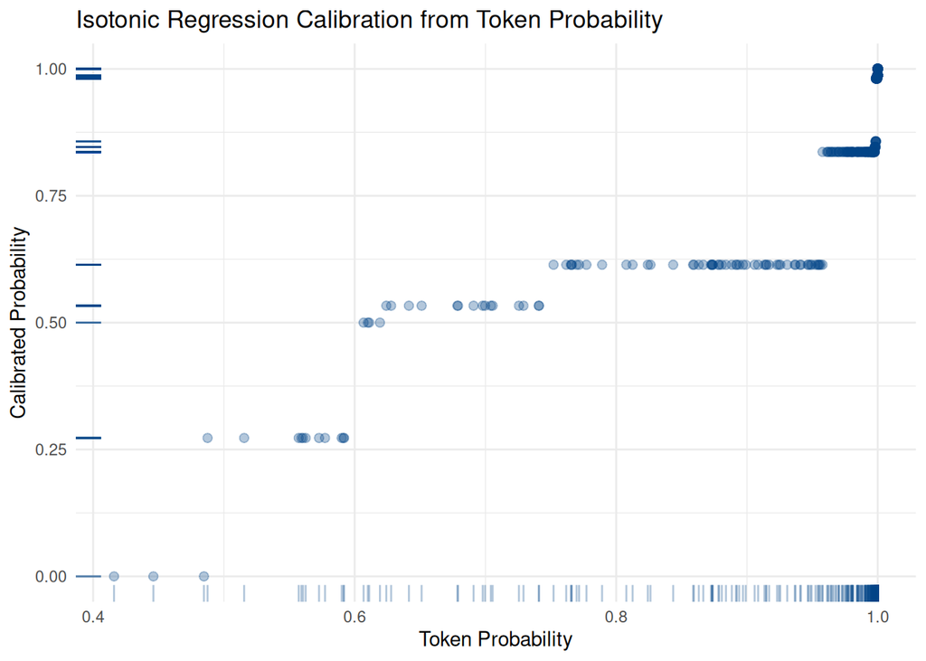

## References

Le Coz, Adrien, Stéphane Herbin, and Faouzi Adjed. 2024. “Confidence Calibration of Classifiers with Many Classes.” *Advances in Neural Information Processing Systems* 37: 77686–725.

Wheeler, Andrew. 2026. “Large Language Models for Mortals: A Practical Guide for Analysts with Python.” *CrimRxiv*.